# Tarea 6 Spark

Mariana Godina Abasolo

### Foto de tu clúster de AWS

- management console

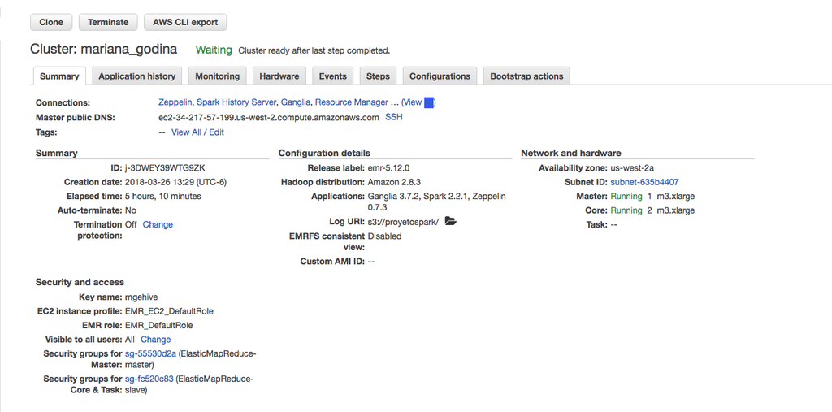

- Lectura de datos zeppelin

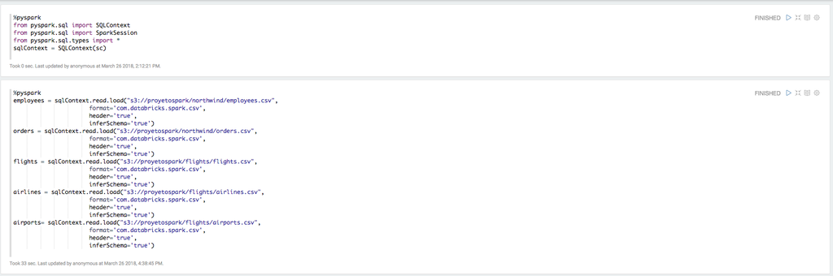

### Ejercicio 1

1. ¿Cuántos “jefes” hay en la tabla empleados?
- Hay 2 “jefes”

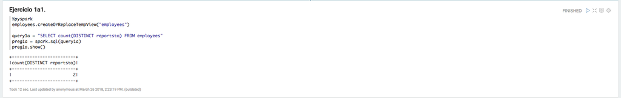

¿Cuáles son estos jefes: número de empleado, nombre, apellido, título, fecha de nacimiento, fecha en que iniciaron en la empresa, ciudad y país? (atributo reportsto, ocupa explode en tu respuesta)

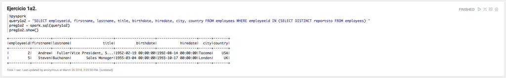

2. ¿Quién es el segundo “mejor” empleado que más órdenes ha generado? (nombre, apellido, título, cuándo entró a la compañía, número de órdenes generadas, número de órdenes generadas por el mejor empleado (número 1))
- La segunda “mejor” empleada es Janet con 127 ordenes generadas.

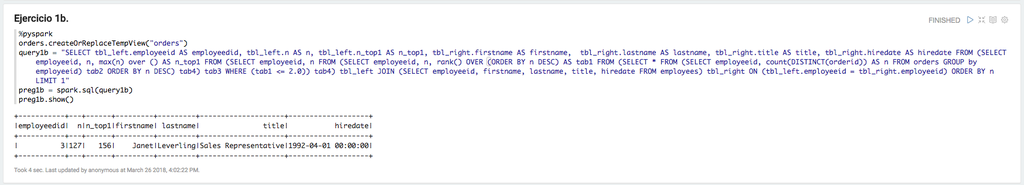

3. ¿Cuál es el delta de tiempo más grande entre una orden y otra?
- 3 días es el tiempo más grande entre una orden y otra

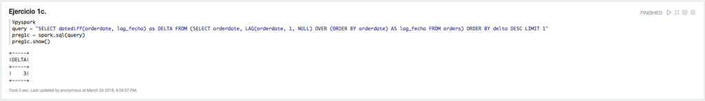

### Ejercicio 2

1. ¿Qué aerolíneas (nombres) llegan al aeropuerto “Honolulu International Airport”?

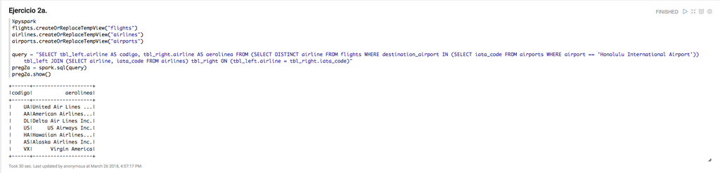

2. ¿En qué horario (hora del día, no importan los minutos) hay salidas del aeropuerto de San Francisco (“SFO”) a “Honolulu International Airport”?

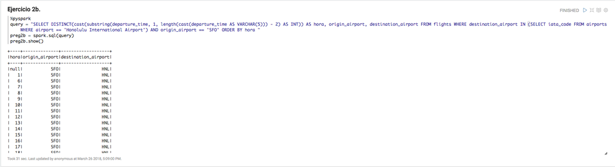

3. ¿Qué día de la semana y en qué aerolínea nos conviene viajar a “Honolulu International Airport” para tener el menor retraso posible?
- El día de la semana que nos conviene viajar a “Honolulu International Airport” es el Domingo por la aerolínea Virgin America.

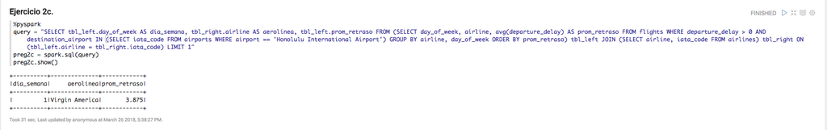

4. ¿Cuál es el aeropuerto con mayor tráfico de entrada?
- El aeropuerto con mayor tráfico es el de atlanta

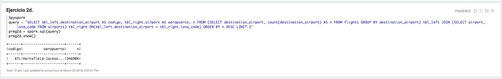

5. ¿Cuál es la aerolínea con mayor retraso de salida por día de la semana?
- Las aerolíneas con mayor retraso son Spirit Air Lines y United Air Lines

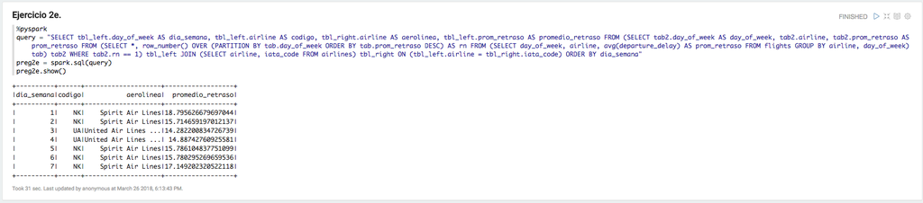

6. ¿Cuál es la tercer aerolínea con menor retraso de salida los lunes (day of week = 2)?
- La tercer aerolínea con menor retraso es Southwest Airlines Co.

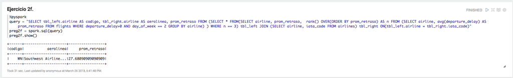

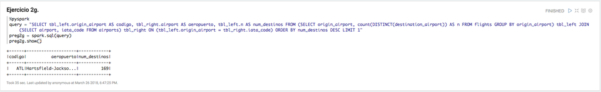